# Assignment 7 - Repeated measure

Author

Md Shakir Moazzem

# 1 Introduction

This assignment will ask you to conduct a repeated measure analysis.

For that, you will first need to watch (and code along with) the following repeated measure video:

- repeated measure lecture: https://youtu.be/-ANqcQhB–A?si=7YeeYqDgcLsj5erW&t=4268 (starts at 01:11:08, watch till the end, about 50 min)
- repeated measure lab part 1: https://youtu.be/GY2e-9M5bFM?si=TIw5F4EF2m9Dx5uK (watch full video, ~1h 50 min)
- repeated measure lab part 2: https://youtu.be/F3vg89ymLeM?si=Zv-RPIdS8mig4EMb (watch full video, ~2h)
- The partial script for the video above is in our GitHub repository, 04-classcode, **03-11_repeatedmeasure_partial.qmd**.
- The data set for this exercise is in oir GitHub repository, 03-classcode, **wheat_nk_balkh_rm.csv**.

**AFTER watching the video and developing the code in class**, then start working on this HW assignment.

# 2 Instructions

- Create on your GitHub a repo named `06_rm`.
- Clone it to your computer, create the necessary subfolders.
- Move the script **03-11_repeatedmeasure_partial.qmd** into the `code` subfolder.
- Move this script into the `code` subfolder
- Move the **wheat_nk_balkh_rm.csv** data set into the `data` subfolder
- On this script, fill your name under the `title` section of the YAML

# 3 Goal of this assignment

The goal is this assignment is for you to **learn about and conduct a full repeated measure analysis**.

Once you finish coding along with the videos, answer the following questions.

# 4 Questions

In class, we decided to use AIC as the metric to select the best model, and this determined the best model to be the one with a general error correlation matrix structure. If we had used BIC as the metric, then the model selected would have been the default model. Here, you are asked to use BIC and thus select the default model as the best, and perform all the steps after model selection. You may copy and paste the class script, and adapt the copied version to implement these changes.

*Answer:* Since we have been instructed to select the default model as the best model based on the BIC, I am going to skip all the intermediary steps and going straight to perform all the steps **after** model selection as per the instruction given in the above question.

# 5 Setup

```r
library(tidyverse) # for data wrangling and plotting
library(car) # for Anova function
library(lme4)
library(broom) # for model residuals extraction
library(emmeans) # for model mean extraction
library(multcomp) # for pairwise comparison letter display
library(nlme) # for repeated measure correlation structures

#We use "lme4" package for mixed effects ANOVA models.
#We use "nlme" package for repeated measures ANOVA models.
```

# 6 Data import and wrangling

```r
#In this data frame, "dap" stands for "days after planting" with 4 levels: 120, 130, 140, 150

rm_rcbd_df <- read_csv("../data/wheat_nk_balkh_rm.csv") %>%
  mutate(across(trt:splot, ~factor(.))) %>%
  mutate(fdap = factor(dap)) #fdap = dap as factor #because we want to have "dap" as both numeric and categorical columns

#1st argument in across() function: select all columns between "trt" and "splot" #2nd argument: ~factor(.) here . is a place holder into which all selected columns (trt:splot) are passed

rm_rcbd_df
```

```
# A tibble: 144 × 10
   trt   block nrate_kgha krate_kgha trtname wplot splot yield_kgha   dap fdap
   <fct> <fct> <fct>      <fct>      <fct>   <fct> <fct>      <dbl> <dbl> <fct>
 1 1     1     0          0          0+0     101   101-1       5488   120 120
 2 1     1     0          0          0+0     101   101-1       5898   130 130
 3 1     1     0          0          0+0     101   101-1       6133   140 140
 4 1     1     0          0          0+0     101   101-1       6151   150 150
 5 2     1     0          30         0+30    102   102-1       4448   120 120
 6 2     1     0          30         0+30    102   102-1       4842   130 130
 7 2     1     0          30         0+30    102   102-1       5057   140 140
 8 2     1     0          30         0+30    102   102-1       5094   150 150
 9 3     1     0          60         0+60    103   103-1       7445   120 120
10 3     1     0          60         0+60    103   103-1       7901   130 130
# ℹ 134 more rows
```

# 7 Models

## 7.1 Default Model

The output for the default model is mentioned below:

```r
mod1_default <- lme(yield_kgha ~ krate_kgha*nrate_kgha*fdap, #Specifying fixed term/effect
                    random = ~ 1 | block/krate_kgha/nrate_kgha, #Specifying random term/effect
                    data = rm_rcbd_df #Specifying where the data is coming from
                    )

mod1_default
```

```
Linear mixed-effects model fit by REML
  Data: rm_rcbd_df
  Log-restricted-likelihood: -588.6984
  Fixed: yield_kgha ~ krate_kgha * nrate_kgha * fdap
                       (Intercept)                       krate_kgha30
                           5144.00                            -933.75
                      krate_kgha60                      nrate_kgha100
                            814.50                           -1198.00
                     nrate_kgha200                            fdap130
                           -144.75                             404.75
                           fdap140                            fdap150
                            606.50                             652.00
        krate_kgha30:nrate_kgha100         krate_kgha60:nrate_kgha100
                           2062.00                             121.50
        krate_kgha30:nrate_kgha200         krate_kgha60:nrate_kgha200
                           1034.75                           -1736.25
              krate_kgha30:fdap130               krate_kgha60:fdap130
                            -23.00                              22.75
              krate_kgha30:fdap140               krate_kgha60:fdap140
                             -9.00                               6.75
              krate_kgha30:fdap150               krate_kgha60:fdap150
                              1.25                               0.75
             nrate_kgha100:fdap130              nrate_kgha200:fdap130
                            -22.25                              -5.25
             nrate_kgha100:fdap140              nrate_kgha200:fdap140
                            -19.50                              -7.00
             nrate_kgha100:fdap150              nrate_kgha200:fdap150
                              3.75                               2.00
krate_kgha30:nrate_kgha100:fdap130 krate_kgha60:nrate_kgha100:fdap130
                             44.75                              -1.25
krate_kgha30:nrate_kgha200:fdap130 krate_kgha60:nrate_kgha200:fdap130
                             28.25                             -36.75
krate_kgha30:nrate_kgha100:fdap140 krate_kgha60:nrate_kgha100:fdap140
                             19.75                              -0.75
krate_kgha30:nrate_kgha200:fdap140 krate_kgha60:nrate_kgha200:fdap140
                             11.75                             -12.75
krate_kgha30:nrate_kgha100:fdap150 krate_kgha60:nrate_kgha100:fdap150
                            -15.75                              -5.00
krate_kgha30:nrate_kgha200:fdap150 krate_kgha60:nrate_kgha200:fdap150
                             -8.50                              -9.25

Random effects:
 Formula: ~1 | block
        (Intercept)
StdDev:    216.6937

 Formula: ~1 | krate_kgha %in% block
        (Intercept)
StdDev:     249.399

 Formula: ~1 | nrate_kgha %in% krate_kgha %in% block
        (Intercept) Residual
StdDev:    581.9363 14.57621

Number of Observations: 144
Number of Groups:
                                block                 krate_kgha %in% block
                                    4                                    12
nrate_kgha %in% krate_kgha %in% block
                                   36
```

## 7.2 General Model

The output for the general model is mentioned below:

```r
mod3_gen <- lme(
  yield_kgha ~ krate_kgha*nrate_kgha*fdap,
  random = ~ 1|block/krate_kgha/nrate_kgha,
  correlation = corSymm(),
  data = rm_rcbd_df)

mod3_gen
```

```
Linear mixed-effects model fit by REML
  Data: rm_rcbd_df
  Log-restricted-likelihood: -581.8339
  Fixed: yield_kgha ~ krate_kgha * nrate_kgha * fdap
                       (Intercept)                       krate_kgha30
                           5144.00                            -933.75
                      krate_kgha60                      nrate_kgha100
                            814.50                           -1198.00
                     nrate_kgha200                            fdap130
                           -144.75                             404.75
                           fdap140                            fdap150
                            606.50                             652.00
        krate_kgha30:nrate_kgha100         krate_kgha60:nrate_kgha100
                           2062.00                             121.50
        krate_kgha30:nrate_kgha200         krate_kgha60:nrate_kgha200
                           1034.75                           -1736.25
              krate_kgha30:fdap130               krate_kgha60:fdap130
                            -23.00                              22.75
              krate_kgha30:fdap140               krate_kgha60:fdap140
                             -9.00                               6.75
              krate_kgha30:fdap150               krate_kgha60:fdap150
                              1.25                               0.75
             nrate_kgha100:fdap130              nrate_kgha200:fdap130
                            -22.25                              -5.25
             nrate_kgha100:fdap140              nrate_kgha200:fdap140
                            -19.50                              -7.00
             nrate_kgha100:fdap150              nrate_kgha200:fdap150
                              3.75                               2.00
krate_kgha30:nrate_kgha100:fdap130 krate_kgha60:nrate_kgha100:fdap130
                             44.75                              -1.25
krate_kgha30:nrate_kgha200:fdap130 krate_kgha60:nrate_kgha200:fdap130
                             28.25                             -36.75
krate_kgha30:nrate_kgha100:fdap140 krate_kgha60:nrate_kgha100:fdap140
                             19.75                              -0.75
krate_kgha30:nrate_kgha200:fdap140 krate_kgha60:nrate_kgha200:fdap140
                             11.75                             -12.75
krate_kgha30:nrate_kgha100:fdap150 krate_kgha60:nrate_kgha100:fdap150
                            -15.75                              -5.00
krate_kgha30:nrate_kgha200:fdap150 krate_kgha60:nrate_kgha200:fdap150
                             -8.50                              -9.25
```

[output cut: 13 more lines]

```

Correlation Structure: General
 Formula: ~1 | block/krate_kgha/nrate_kgha
 Parameter estimate(s):
 Correlation:
  1      2      3
2  0.617
3 -0.050  0.304
4  0.187  0.203 -0.394
Number of Observations: 144
Number of Groups:
                                block                 krate_kgha %in% block
                                    4                                    12
nrate_kgha %in% krate_kgha %in% block
                                   36
```

## 7.3 Q1: Include here the residual assessment of the default model. Include each plot and its interpretation. How do these residuals from the default model visually compare to those from the general model?

### 7.3.1 Checking residuals for the general model

```r
library(broom.mixed)

mod3_gen_resid <- augment(mod3_gen) %>%
  mutate(.stdresid=resid(mod3_gen,
                         type="pearson",
                         scaled=T)) # resid() = Standardized residual (not studentized residual)

mod3_gen_resid
```

```
# A tibble: 144 × 14
   trt   block nrate_kgha krate_kgha trtname wplot splot yield_kgha   dap fdap
   <fct> <fct> <fct>      <fct>      <fct>   <fct> <fct>      <dbl> <dbl> <fct>
 1 1     1     0          0          0+0     101   101-1       5488   120 120
 2 1     1     0          0          0+0     101   101-1       5898   130 130
 3 1     1     0          0          0+0     101   101-1       6133   140 140
 4 1     1     0          0          0+0     101   101-1       6151   150 150
 5 2     1     0          30         0+30    102   102-1       4448   120 120
 6 2     1     0          30         0+30    102   102-1       4842   130 130
 7 2     1     0          30         0+30    102   102-1       5057   140 140
 8 2     1     0          30         0+30    102   102-1       5094   150 150
 9 3     1     0          60         0+60    103   103-1       7445   120 120
10 3     1     0          60         0+60    103   103-1       7901   130 130
# ℹ 134 more rows
# ℹ 4 more variables: .fitted <dbl>, .resid <dbl>, .fixed <dbl>,
#   .stdresid <dbl>
```

### 7.3.2 Checking residuals for the default model

```r
library(broom.mixed)

mod1_default_resid <- augment(mod1_default) %>%
  mutate(.stdresid=resid(mod1_default,
                         type="pearson",
                         scaled=T)) # resid() = Standardized residual (not studentized residual)

mod1_default_resid
```

```
# A tibble: 144 × 14
   trt   block nrate_kgha krate_kgha trtname wplot splot yield_kgha   dap fdap
   <fct> <fct> <fct>      <fct>      <fct>   <fct> <fct>      <dbl> <dbl> <fct>
 1 1     1     0          0          0+0     101   101-1       5488   120 120
 2 1     1     0          0          0+0     101   101-1       5898   130 130
 3 1     1     0          0          0+0     101   101-1       6133   140 140
 4 1     1     0          0          0+0     101   101-1       6151   150 150
 5 2     1     0          30         0+30    102   102-1       4448   120 120
 6 2     1     0          30         0+30    102   102-1       4842   130 130
 7 2     1     0          30         0+30    102   102-1       5057   140 140
 8 2     1     0          30         0+30    102   102-1       5094   150 150
 9 3     1     0          60         0+60    103   103-1       7445   120 120
10 3     1     0          60         0+60    103   103-1       7901   130 130
# ℹ 134 more rows
# ℹ 4 more variables: .fitted <dbl>, .resid <dbl>, .fixed <dbl>,
#   .stdresid <dbl>
```

### 7.3.3 Block random effects are iid ~ N(0,var_a)

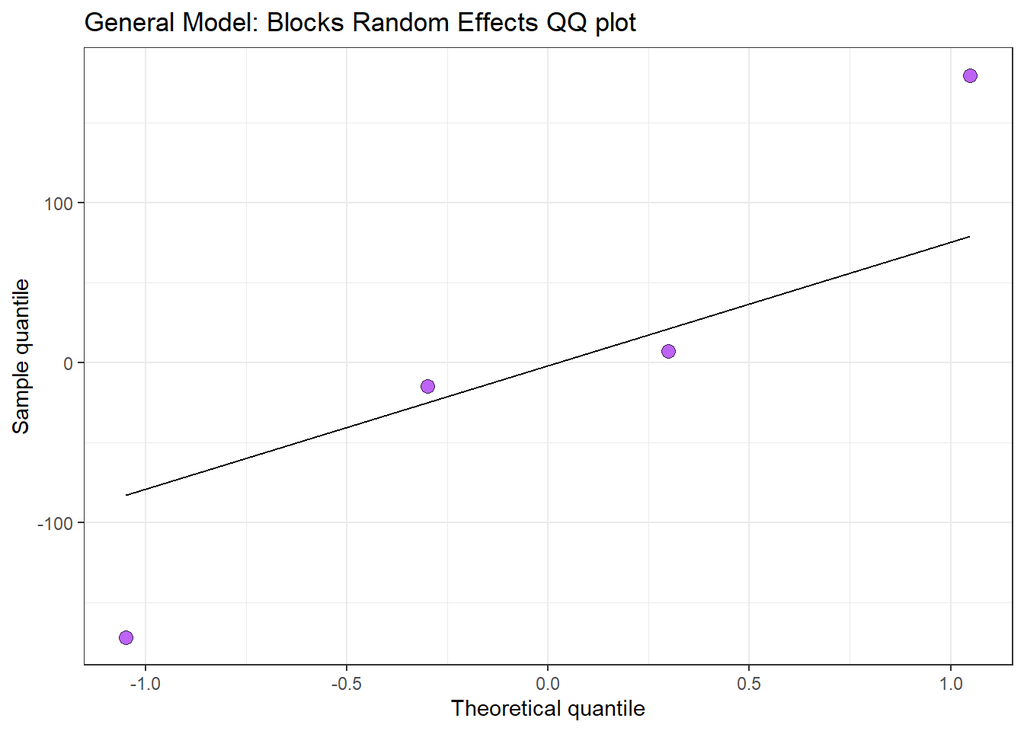

```r
ranef(mod3_gen)[[1]] %>%
  ggplot(aes(sample=`(Intercept)`))+
  stat_qq(  shape = 21,
            fill = "purple",
            size = 3,
            alpha = .7
  )+
  stat_qq_line()+
  labs(x = "Theoretical quantile",
       y = "Sample quantile",
       title = "General Model: Blocks Random Effects QQ plot")+
  theme_bw()
```

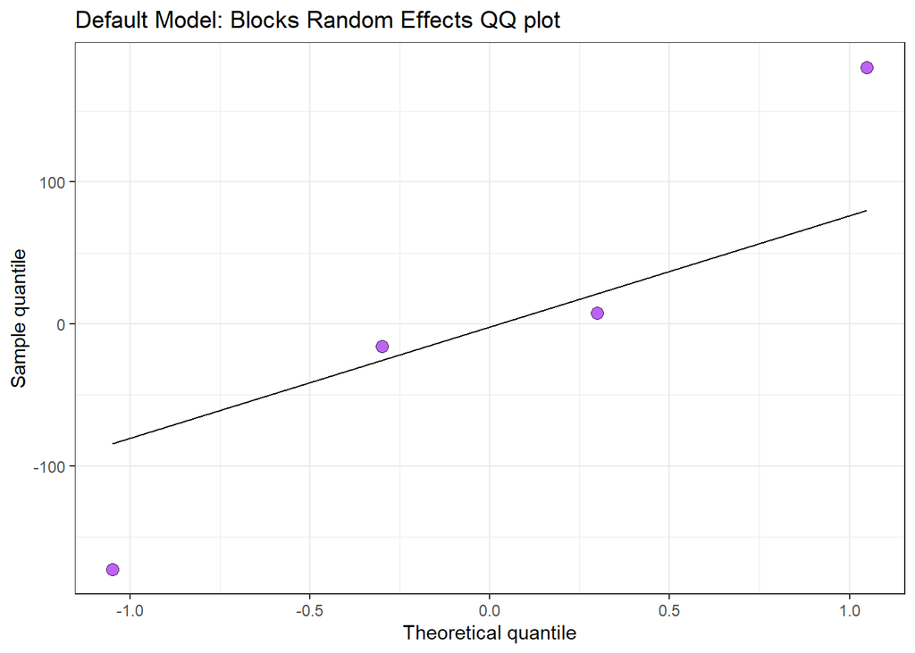

```r
ranef(mod1_default)[[1]] %>%
  ggplot(aes(sample=`(Intercept)`))+
  stat_qq(  shape = 21,
            fill = "purple",
            size = 3,
            alpha = .7
  )+
  stat_qq_line()+
  labs(x = "Theoretical quantile",
       y = "Sample quantile",
       title = "Default Model: Blocks Random Effects QQ plot")+
  theme_bw()
```

*Visual comparison of residuals between default and general model:* For the random effect associated with Block, the residuals in the QQ plot of the default model appear to be very v-e-r-y similar (if not the same) to those of the general model QQ plot.

### 7.3.4 Block:krate random effects are iid ~ N(0,var_b)

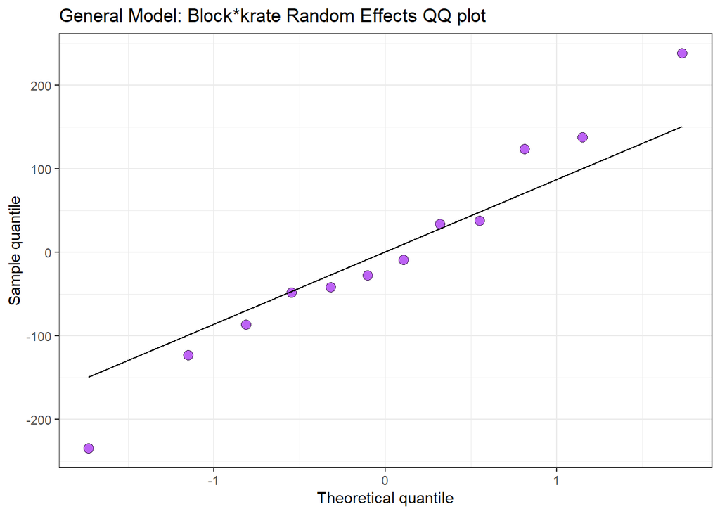

```r
ranef(mod3_gen)[[2]] %>%
  ggplot(aes(sample=`(Intercept)`))+
  stat_qq(  shape = 21,
            fill = "purple",
            size = 3,
            alpha = .7
  )+
  stat_qq_line()+
  labs(x = "Theoretical quantile",
       y = "Sample quantile",
       title = "General Model: Block*krate Random Effects QQ plot")+
  theme_bw()
```

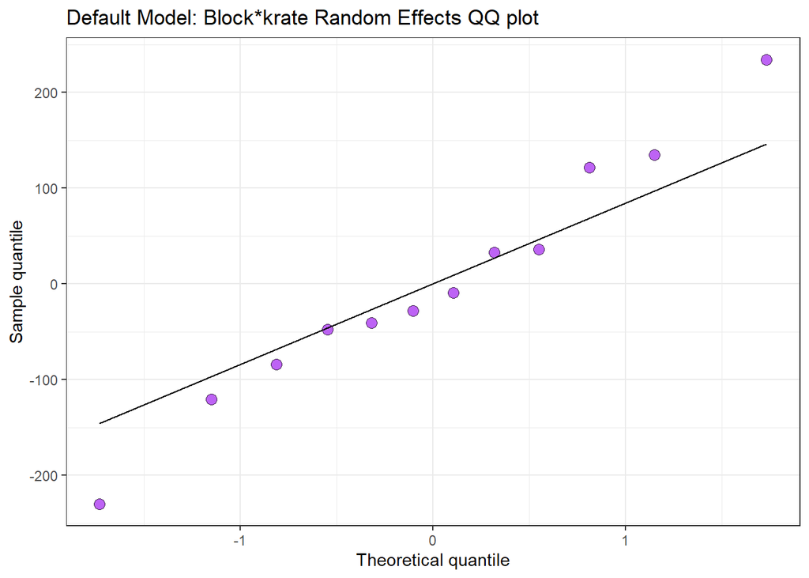

```r
ranef(mod1_default)[[2]] %>%
  ggplot(aes(sample=`(Intercept)`))+
  stat_qq(  shape = 21,
            fill = "purple",
            size = 3,
            alpha = .7
  )+
  stat_qq_line()+
  labs(x = "Theoretical quantile",
       y = "Sample quantile",
       title = "Default Model: Block*krate Random Effects QQ plot")+
  theme_bw()
```

*Interpretation:* In the QQ plot for the random effect associated with potassium rates nested within blocks shown above, the residuals appear to fall closely around the QQ line with no strong curvature pattern. Although there appears to be slight deviations on two tails from QQ line, they are not too extreme to be worrisome. Hence, the residual normality assumption appears to hold.

*Visual comparison of residuals between default and general model:* For the random effects associated with potassium rates nested within blocks, the residuals in the QQ plot for the default model appear to be very v-e-r-y similar (if not the same) to those of the general model QQ plot.

### 7.3.5 Block:krate:nrate random effects are iid ~ N(0,var_c)

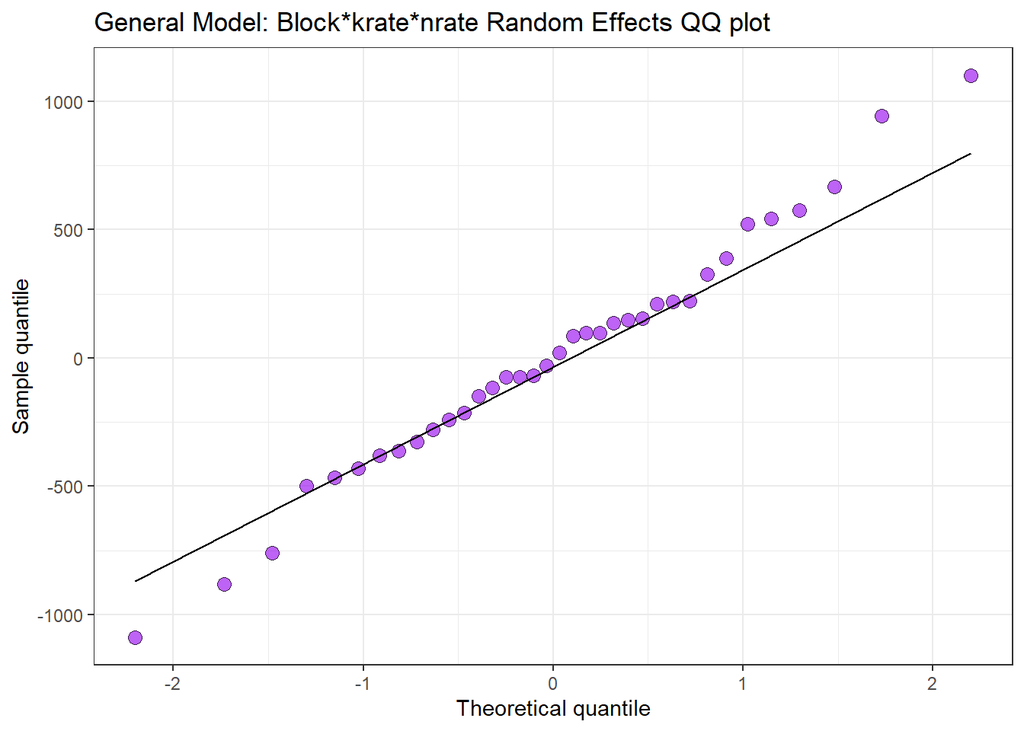

```r
ranef(mod3_gen)[[3]] %>%
  ggplot(aes(sample=`(Intercept)`))+
  stat_qq(  shape = 21,
            fill = "purple",
            size = 3,
            alpha = .7
  )+
  stat_qq_line()+
  labs(x = "Theoretical quantile",
       y = "Sample quantile",
       title = "General Model: Block*krate*nrate Random Effects QQ plot")+
  theme_bw()
```

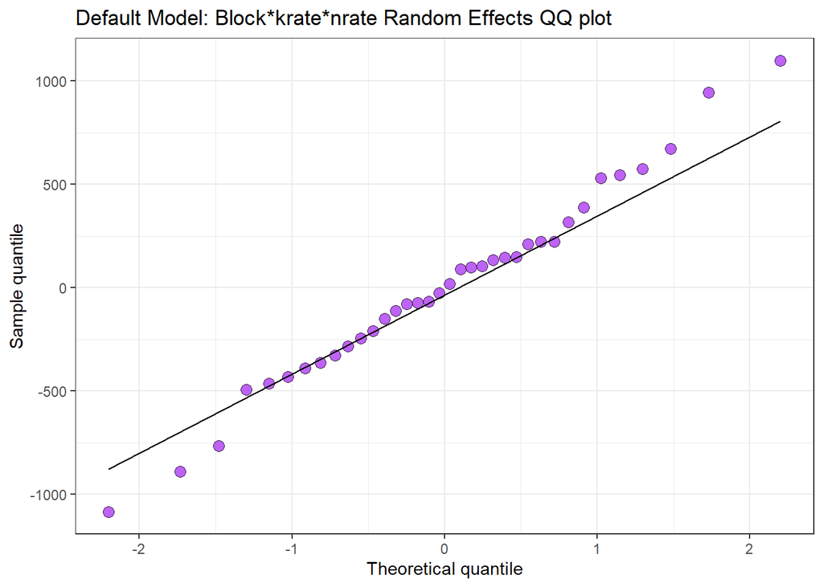

```r
ranef(mod1_default)[[3]] %>%
  ggplot(aes(sample=`(Intercept)`))+
  stat_qq(  shape = 21,
            fill = "purple",
            size = 3,
            alpha = .7
  )+
  stat_qq_line()+
  labs(x = "Theoretical quantile",
       y = "Sample quantile",
       title = "Default Model: Block*krate*nrate Random Effects QQ plot")+
  theme_bw()
```

*Interpretation:* In the QQ plot for the random effect associated with nitrogen rates nested within potassium rates nested within blocks shown above, the residuals appear to fall closely around the QQ line with no strong curvature pattern. Although there appears to be slight deviations on two tails from QQ line , they are not too extreme to be worrisome. Hence, the residual normality assumption appears to hold.

*Visual comparison of residuals between default and general model:* For the random effects associated with nitrogen rates nested within potassium rates nested within blocks, the residuals in the QQ plot for the default model appear to be very v-e-r-y similar (if not the same) to those of the general model QQ plot.

### 7.3.6 Within-group errors are iid ~ N(0, var_e)

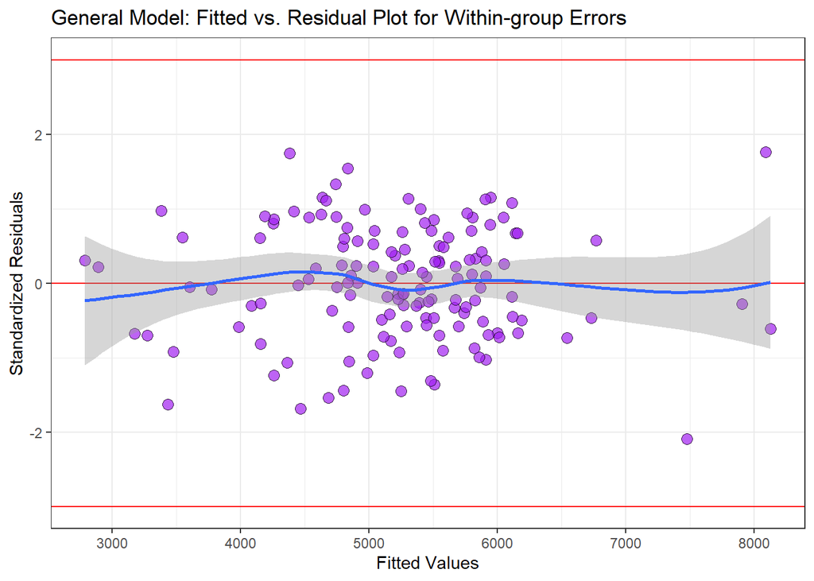

```r
ggplot(mod3_gen_resid, aes(x=.fitted, y=.stdresid))+
  geom_hline(yintercept = 0, color="red")+
  geom_point(shape = 21,
             fill = "purple",
             size = 3,
             alpha = .7)+
  geom_smooth()+
  geom_hline(yintercept = c(-3,3), color = "red")+
  labs(y = "Standardized Residuals",
       x = "Fitted Values",
       title = "General Model: Fitted vs. Residual Plot for Within-group Errors")+
  theme_bw()
```

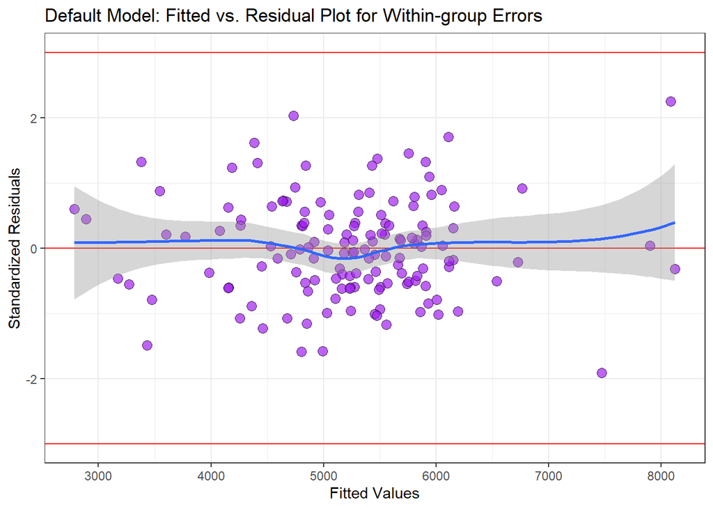

```r
ggplot(mod1_default_resid, aes(x=.fitted, y=.stdresid))+
  geom_hline(yintercept = 0, color="red")+
  geom_point(shape = 21,
             fill = "purple",
             size = 3,
             alpha = .7)+
  geom_smooth()+
  geom_hline(yintercept = c(-3,3), color = "red")+
  labs(y = "Standardized Residuals",
       x = "Fitted Values",
       title = "Default Model: Fitted vs. Residual Plot for Within-group Errors")+
  theme_bw()
```

Interpretation of model assumptions:

*Residual independence:*

From the fitted vs. residual plot shown above, we see:

- no clear pattern of residuals
- random cloud of points of residuals
- the error band for the smooth line comprises of 0 along the x-axis

Hence, the residual independence assumption appears to hold.

*Residual homogeneous variance/ variance homogeneity/ homoscedasticity:*

From the fitted vs. residual plot shown above, we see:

- spread of residuals seems to be even along y-axis
- spread of residuals seems constant (i.e., neither increasing nor decreasing) along x-axis
- no clear pattern of residuals
- random cloud of points of residuals
- the error band for the smooth line comprises of 0 along the x-axis

Hence, the residual homogeneous variance/ variance homogeneity/ homoscedasticity assumption appears to hold.

*Outlier detection:*

From the fitted vs. residual plot shown above, we see that all residuals fall within [-3, 3] interval along the y-axis. Hence, there is no outlier present to skew the model interpretation.

*Visual comparison of residuals between default and general model:* For the fitted vs. residual plots shown above, the residuals in the fitted vs. residual plot for the default model appear to be very v-e-r-y similar to those of the fitted vs. residual plot for the general model.

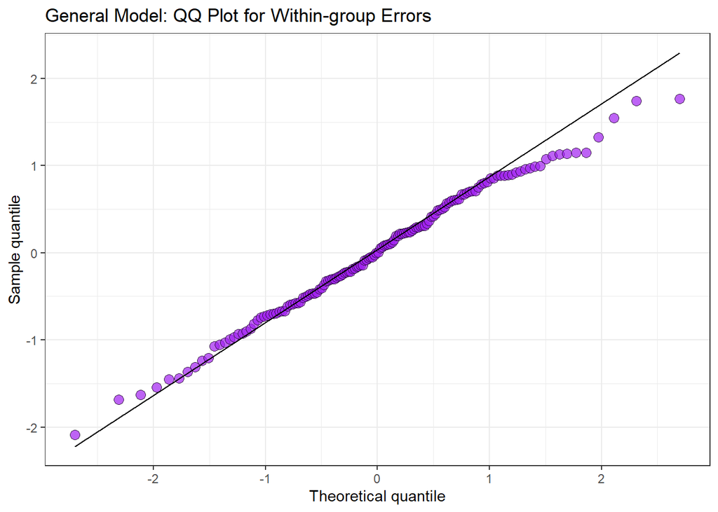

```r
ggplot(mod3_gen_resid, aes(sample=.stdresid))+
  stat_qq(  shape = 21,
            fill = "purple",
            size = 3,
            alpha = .7
  )+
  stat_qq_line()+
  labs(x = "Theoretical quantile",
       y = "Sample quantile",
       title = "General Model: QQ Plot for Within-group Errors")+
  theme_bw()
```

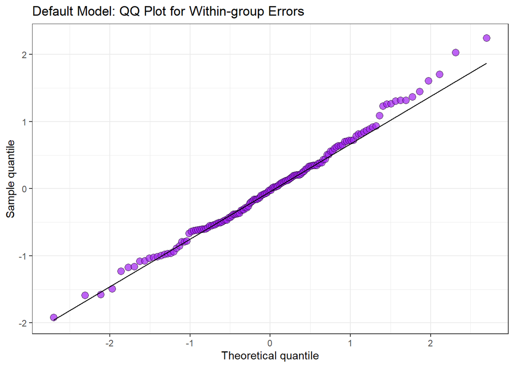

```r
ggplot(mod1_default_resid, aes(sample=.stdresid))+
  stat_qq(  shape = 21,
            fill = "purple",
            size = 3,
            alpha = .7
  )+
  stat_qq_line()+
  labs(x = "Theoretical quantile",
       y = "Sample quantile",
       title = "Default Model: QQ Plot for Within-group Errors")+
  theme_bw()
```

*Residual normality:*

In the QQ plot show above, the residuals fall closely around the QQ line with no strong curvature pattern. Although there appears to be very slight deviations on the upper tail from QQ line, they are not too extreme/drastic to be worrisome. Hence, the residual normality assumption appears to hold.

*Visual comparison of residuals between default and general model:* The residuals in the QQ plot for the default model appear to be similar to those of the QQ plot for the general model, although there are slight visible differences in the pattern of residuals along their two tails from the QQ line: the residuals along the upper tail of the default model QQ plot are situated upward to the QQ line, whereas the those for the general model QQ plot are situated downward to the QQ line.

## 7.4 Q2: Include here the ANOVA table from the default model. How does it compare with the ANOVA table from the general model?

### 7.4.1 ANOVA Table for General Model

```r
Anova(mod3_gen, type = 3)
```

```
Analysis of Deviance Table (Type III tests)

Response: yield_kgha
                              Chisq Df Pr(>Chisq)
(Intercept)                 236.014  1  < 2.2e-16 ***
krate_kgha                   15.241  2  0.0004904 ***
nrate_kgha                   10.117  2  0.0063542 **
fdap                       6072.814  3  < 2.2e-16 ***
krate_kgha:nrate_kgha        32.853  4  1.280e-06 ***
krate_kgha:fdap              29.594  6  4.694e-05 ***
nrate_kgha:fdap               7.159  6  0.3063932
krate_kgha:nrate_kgha:fdap   39.863 12  7.576e-05 ***
---
Signif. codes:  0 '***' 0.001 '**' 0.01 '*' 0.05 '.' 0.1 ' ' 1
```

### 7.4.2 ANOVA Table for Default Model

```r
Anova(mod1_default, type = 3)
```

```
Analysis of Deviance Table (Type III tests)

Response: yield_kgha
                               Chisq Df Pr(>Chisq)
(Intercept)                 236.2469  1  < 2.2e-16 ***
krate_kgha                   15.2651  2  0.0004844 ***
nrate_kgha                   10.0945  2  0.0064269 **
fdap                       4992.2100  3  < 2.2e-16 ***
krate_kgha:nrate_kgha        32.7791  4  1.326e-06 ***
krate_kgha:fdap              13.3117  6  0.0383441 *
nrate_kgha:fdap               5.2618  6  0.5106973
krate_kgha:nrate_kgha:fdap   19.8741 12  0.0695054 .
---
Signif. codes:  0 '***' 0.001 '**' 0.01 '*' 0.05 '.' 0.1 ' ' 1
```

*Answer:*

# 8 Submitting your work

Once you have developed all the code and answers, make sure to Render this quarto file.

**Notes on rendering**:

- Make sure to render your work and inspect how the final html look like.
- If it does not look professional for whatever reason, then fix the issue, re-render it, recheck.
- Only send me your work once your html file looks professional.
  - **DO NOT** delete the file’s heading levels (# and ##). They set up the proper heading 1 and 2 levels, and I use them to guide my grading.
  - If a given chunk is also outputting warnings or messages, inhibit this behavior by changing the chunk options `message` and `warning` to `FALSE` (I’ll demo this in a moment).
  - If, after rendered, 2 lines of text are connected and you wish to “break line” between them, add 2 extra spaces after the first one (I’lld demo this in a moment).

After rendering, an .html file will be created on your `code` folder.

Rename this file to `Assignment-07-rm-LASTNAME.html`.

For ex., mine would be `Assignment-07-rm-Bastos.html`.

Submit your work by uploading the **html** file to **eLC Assigment #7 - Repeated measure** by Mar 25 11:59 pm.